# Prosper Loans Data Exploration

## Introduction

> This data set contains 113,937 loans with 81 variables on each loan, including loan amount, borrower rate (or interest rate), current loan status, borrower income, and many others. The aim of this project is to use Python data science and data visualization libraries to explore the dataset’s variables and understand the data’s structure, oddities, patterns, and relationships.

## Preliminary Wrangling

```python
# Import all packages and set plots to be embedded inline
import numpy as np
import pandas as pd
import matplotlib.pyplot as plt
import seaborn as sb
pd.set_option('max_rows', None)
pd.set_option('max_columns', None)

%matplotlib inline

import warnings
warnings.filterwarnings('ignore')
```

```python
loan = pd.read_csv("LoansData.csv")
print(loan.shape)
## Here, we load the data into a pandas dataframe
```

```
(113937, 81)
```

```python
loan.head()
```

|  | ListingKey | ListingNumber | ListingCreationDate | CreditGrade | Term | LoanStatus | ClosedDate | BorrowerAPR | BorrowerRate | LenderYield | EstimatedEffectiveYield | EstimatedLoss | EstimatedReturn | ProsperRating (numeric) | ProsperRating (Alpha) | ProsperScore | ListingCategory (numeric) | BorrowerState | Occupation | EmploymentStatus | EmploymentStatusDuration | IsBorrowerHomeowner | CurrentlyInGroup | GroupKey | DateCreditPulled | CreditScoreRangeLower | CreditScoreRangeUpper | FirstRecordedCreditLine | CurrentCreditLines | … |
| --- | --- | --- | --- | --- | --- | --- | --- | --- | --- | --- | --- | --- | --- | --- | --- | --- | --- | --- | --- | --- | --- | --- | --- | --- | --- | --- | --- | --- | --- | --- |
| 0 | 1021339766868145413AB3B | 193129 | 2007-08-26 19:09:29.263000000 | C | 36 | Completed | 2009-08-14 00:00:00 | 0.16516 | 0.1580 | 0.1380 | NaN | NaN | NaN | NaN | NaN | NaN | 0 | CO | Other | Self-employed | 2.0 | True | True | NaN | 2007-08-26 18:41:46.780000000 | 640.0 | 659.0 | 2001-10-11 00:00:00 | 5.0 | … |
| 1 | 10273602499503308B223C1 | 1209647 | 2014-02-27 08:28:07.900000000 | NaN | 36 | Current | NaN | 0.12016 | 0.0920 | 0.0820 | 0.07960 | 0.0249 | 0.05470 | 6.0 | A | 7.0 | 2 | CO | Professional | Employed | 44.0 | False | False | NaN | 2014-02-27 08:28:14 | 680.0 | 699.0 | 1996-03-18 00:00:00 | 14.0 | … |
| 2 | 0EE9337825851032864889A | 81716 | 2007-01-05 15:00:47.090000000 | HR | 36 | Completed | 2009-12-17 00:00:00 | 0.28269 | 0.2750 | 0.2400 | NaN | NaN | NaN | NaN | NaN | NaN | 0 | GA | Other | Not available | NaN | False | True | 783C3371218786870A73D20 | 2007-01-02 14:09:10.060000000 | 480.0 | 499.0 | 2002-07-27 00:00:00 | NaN | … |
| 3 | 0EF5356002482715299901A | 658116 | 2012-10-22 11:02:35.010000000 | NaN | 36 | Current | NaN | 0.12528 | 0.0974 | 0.0874 | 0.08490 | 0.0249 | 0.06000 | 6.0 | A | 9.0 | 16 | GA | Skilled Labor | Employed | 113.0 | True | False | NaN | 2012-10-22 11:02:32 | 800.0 | 819.0 | 1983-02-28 00:00:00 | 5.0 | … |
| 4 | 0F023589499656230C5E3E2 | 909464 | 2013-09-14 18:38:39.097000000 | NaN | 36 | Current | NaN | 0.24614 | 0.2085 | 0.1985 | 0.18316 | 0.0925 | 0.09066 | 3.0 | D | 4.0 | 2 | MN | Executive | Employed | 44.0 | True | False | NaN | 2013-09-14 18:38:44 | 680.0 | 699.0 | 2004-02-20 00:00:00 | 19.0 | … |

```python
((loan.isna().sum()/loan.shape[0])*100).head(15)
```

```
ListingKey                  0.000000
ListingNumber               0.000000
ListingCreationDate         0.000000
CreditGrade                74.588588
Term                        0.000000
LoanStatus                  0.000000
ClosedDate                 51.649596
BorrowerAPR                 0.021942
BorrowerRate                0.000000
LenderYield                 0.000000
EstimatedEffectiveYield    25.526387
EstimatedLoss              25.526387
EstimatedReturn            25.526387
ProsperRating (numeric)    25.526387
ProsperRating (Alpha)      25.526387
dtype: float64
```

```python
zer = []
for i in range(len(loan.columns)):
    zeros = ((loan[loan.columns[i]] == 0).sum()/loan.shape[0])
    zer.append(zeros)
```

```python
data = {'Col_Name': loan.columns,'Zero_Percentage':zer}
df = pd.DataFrame(data)
df=df.style.format({'Zero_Percentage': "{:.2%}"})
df
```

|  | Col_Name | Zero_Percentage |
| --- | --- | --- |
| 0 | ListingKey | 0.00% |
| 1 | ListingNumber | 0.00% |
| 2 | ListingCreationDate | 0.00% |
| 3 | CreditGrade | 0.00% |
| 4 | Term | 0.00% |
| 5 | LoanStatus | 0.00% |
| 6 | ClosedDate | 0.00% |
| 7 | BorrowerAPR | 0.00% |
| 8 | BorrowerRate | 0.01% |
| 9 | LenderYield | 0.01% |
| 10 | EstimatedEffectiveYield | 0.00% |
| 11 | EstimatedLoss | 0.00% |
| 12 | EstimatedReturn | 0.00% |
| 13 | ProsperRating (numeric) | 0.00% |
| 14 | ProsperRating (Alpha) | 0.00% |
| 15 | ProsperScore | 0.00% |
| 16 | ListingCategory (numeric) | 14.89% |
| 17 | BorrowerState | 0.00% |
| 18 | Occupation | 0.00% |
| 19 | EmploymentStatus | 0.00% |
| 20 | EmploymentStatusDuration | 1.35% |
| 21 | IsBorrowerHomeowner | 49.55% |
| 22 | CurrentlyInGroup | 88.84% |
| 23 | GroupKey | 0.00% |
| 24 | DateCreditPulled | 0.00% |
| 25 | CreditScoreRangeLower | 0.12% |
| 26 | CreditScoreRangeUpper | 0.00% |
| 27 | FirstRecordedCreditLine | 0.00% |
| 28 | CurrentCreditLines | 0.34% |
| 29 | OpenCreditLines | 0.49% |

[output cut: 51 more lines]

- The dataset has 113937 observations and 81 variables
- For the purpose of this analysis, I selected only the variables that'd help understand the data better
- Possible variables of interest are : Term, LoanStatus, BorrowerAPR, EstimatedReturn, ProsperRating, ProsperRating, ListingCategory, BorrowerState, Occupation, EmploymentStatus, and some others.
- I identified 20 variables that carry the potential of unleashing the most pertinent insights in the dataset.

**NB: I spent a couple of hours reading the variable description [here](https://docs.google.com/spreadsheets/d/1gDyi_L4UvIrLTEC6Wri5nbaMmkGmLQBk-Yx3z0XDEtI/edit#gid=0), going through the dataset visually (in Excel), and selected those 20 features for the purpose of this analysis. I also dropped some features becasue of they contain many missing values (>70%), some have many zeros - as shown in the analysis performed above**

- Having just 20 variables would speed up our analysis, make it less cumbersome, and foster better understanding.

```python
## selecting the variables needed for this analysis

loan_data = loan[["Term","LoanStatus","CreditGrade","BorrowerAPR","EstimatedReturn","ProsperRating (numeric)",
                  "ProsperRating (Alpha)","ListingCategory (numeric)","BorrowerState","Occupation",
                  "EmploymentStatus","EmploymentStatusDuration","RevolvingCreditBalance","LoanOriginationQuarter",
                  "IsBorrowerHomeowner","BankcardUtilization","StatedMonthlyIncome",
                  "LoanMonthsSinceOrigination","LoanOriginalAmount","Investors"]]

loan_data.head()
```

|  | Term | LoanStatus | CreditGrade | BorrowerAPR | EstimatedReturn | ProsperRating (numeric) | ProsperRating (Alpha) | ListingCategory (numeric) | BorrowerState | Occupation | EmploymentStatus | EmploymentStatusDuration | RevolvingCreditBalance | LoanOriginationQuarter | IsBorrowerHomeowner | BankcardUtilization | StatedMonthlyIncome | LoanMonthsSinceOrigination | LoanOriginalAmount | Investors |
| --- | --- | --- | --- | --- | --- | --- | --- | --- | --- | --- | --- | --- | --- | --- | --- | --- | --- | --- | --- | --- |
| 0 | 36 | Completed | C | 0.16516 | NaN | NaN | NaN | 0 | CO | Other | Self-employed | 2.0 | 0.0 | Q3 2007 | True | 0.00 | 3083.333333 | 78 | 9425 | 258 |
| 1 | 36 | Current | NaN | 0.12016 | 0.05470 | 6.0 | A | 2 | CO | Professional | Employed | 44.0 | 3989.0 | Q1 2014 | False | 0.21 | 6125.000000 | 0 | 10000 | 1 |
| 2 | 36 | Completed | HR | 0.28269 | NaN | NaN | NaN | 0 | GA | Other | Not available | NaN | NaN | Q1 2007 | False | NaN | 2083.333333 | 86 | 3001 | 41 |
| 3 | 36 | Current | NaN | 0.12528 | 0.06000 | 6.0 | A | 16 | GA | Skilled Labor | Employed | 113.0 | 1444.0 | Q4 2012 | True | 0.04 | 2875.000000 | 16 | 10000 | 158 |
| 4 | 36 | Current | NaN | 0.24614 | 0.09066 | 3.0 | D | 2 | MN | Executive | Employed | 44.0 | 6193.0 | Q3 2013 | True | 0.81 | 9583.333333 | 6 | 15000 | 20 |

### A little more wrangling 😎

### Issue #1

The values in the CreditGrade column are the missing values in Prosper Rating(Alpha) column

### Define

Combine the two columns together and drop one of them

```python
loan_data['ProsperRating (Alpha)'].isna().sum()
```

```
29084
```

```python
loan_data['ProsperRating (Alpha)'] = loan_data['ProsperRating (Alpha)'].combine_first(loan_data['CreditGrade'])

loan_data.drop('CreditGrade', axis =1, inplace =True)
```

### Test

```python
loan_data['ProsperRating (Alpha)'].isna().sum()
```

```
131
```

```python
loan_data.head(2)
```

|  | Term | LoanStatus | BorrowerAPR | EstimatedReturn | ProsperRating (numeric) | ProsperRating (Alpha) | ListingCategory (numeric) | BorrowerState | Occupation | EmploymentStatus | EmploymentStatusDuration | RevolvingCreditBalance | LoanOriginationQuarter | IsBorrowerHomeowner | BankcardUtilization | StatedMonthlyIncome | LoanMonthsSinceOrigination | LoanOriginalAmount | Investors |
| --- | --- | --- | --- | --- | --- | --- | --- | --- | --- | --- | --- | --- | --- | --- | --- | --- | --- | --- | --- |
| 0 | 36 | Completed | 0.16516 | NaN | NaN | C | 0 | CO | Other | Self-employed | 2.0 | 0.0 | Q3 2007 | True | 0.00 | 3083.333333 | 78 | 9425 | 258 |
| 1 | 36 | Current | 0.12016 | 0.0547 | 6.0 | A | 2 | CO | Professional | Employed | 44.0 | 3989.0 | Q1 2014 | False | 0.21 | 6125.000000 | 0 | 10000 | 1 |

We now have just 131 missing values, down from over 29,000. Also, CreditGrade has been dropped. Beautiful!

### Issue #2

### Define

Check for all missing values and try to fill them up

### Code

```python
loan_data.isna().sum()
```

```
Term                              0
LoanStatus                        0
BorrowerAPR                      25
EstimatedReturn               29084
ProsperRating (numeric)       29084
ProsperRating (Alpha)           131
ListingCategory (numeric)         0
BorrowerState                  5515
Occupation                     3588
EmploymentStatus               2255
EmploymentStatusDuration       7625
RevolvingCreditBalance         7604
LoanOriginationQuarter            0
IsBorrowerHomeowner               0
BankcardUtilization            7604
StatedMonthlyIncome               0
LoanMonthsSinceOrigination        0
LoanOriginalAmount                0
Investors                         0
dtype: int64
```

```python
obj = loan_data.columns[loan_data.dtypes==object]

for i in obj:
    if loan_data[i].isna().sum()>1:
        loan_data[i].fillna(loan_data[i].mode()[0], inplace = True)
```

```python
numeric = loan_data.columns[loan_data.dtypes!=object]

for i in numeric:
    if loan_data[i].isna().sum()>1:
        loan_data[i].fillna(loan_data[i].mean(), inplace = True)
```

### Test

```python
loan_data.isna().sum()
```

```
Term                          0
LoanStatus                    0
BorrowerAPR                   0
EstimatedReturn               0
ProsperRating (numeric)       0
ProsperRating (Alpha)         0
ListingCategory (numeric)     0
BorrowerState                 0
Occupation                    0
EmploymentStatus              0
EmploymentStatusDuration      0
RevolvingCreditBalance        0
LoanOriginationQuarter        0
IsBorrowerHomeowner           0
BankcardUtilization           0
StatedMonthlyIncome           0
LoanMonthsSinceOrigination    0
LoanOriginalAmount            0
Investors                     0
dtype: int64
```

Every feature with one or more mssing value has been dealt with.

### Issue #3

Prosper_rating (numeric) and prosper_rating(alpha) represent the same thing "As found in the variable description, each numeric rating is represented as follows: 0 - N/A, 1 - HR, 2 - E, 3 - D, 4 - C, 5 - B, 6 - A, 7 - AA"

### Define

Drop one of them, preferrably the one with the numeric type

### Code

```python
loan_data.drop('ProsperRating (numeric)', axis =1, inplace =True)
```

### Test

```python
loan_data.head()
## now, the dropped column is missing from the table
```

|  | Term | LoanStatus | BorrowerAPR | EstimatedReturn | ProsperRating (Alpha) | ListingCategory (numeric) | BorrowerState | Occupation | EmploymentStatus | EmploymentStatusDuration | RevolvingCreditBalance | LoanOriginationQuarter | IsBorrowerHomeowner | BankcardUtilization | StatedMonthlyIncome | LoanMonthsSinceOrigination | LoanOriginalAmount | Investors |
| --- | --- | --- | --- | --- | --- | --- | --- | --- | --- | --- | --- | --- | --- | --- | --- | --- | --- | --- |
| 0 | 36 | Completed | 0.16516 | 0.096068 | C | 0 | CO | Other | Self-employed | 2.000000 | 0.000000 | Q3 2007 | True | 0.000000 | 3083.333333 | 78 | 9425 | 258 |
| 1 | 36 | Current | 0.12016 | 0.054700 | A | 2 | CO | Professional | Employed | 44.000000 | 3989.000000 | Q1 2014 | False | 0.210000 | 6125.000000 | 0 | 10000 | 1 |
| 2 | 36 | Completed | 0.28269 | 0.096068 | HR | 0 | GA | Other | Not available | 96.071582 | 17598.706751 | Q1 2007 | False | 0.561309 | 2083.333333 | 86 | 3001 | 41 |
| 3 | 36 | Current | 0.12528 | 0.060000 | A | 16 | GA | Skilled Labor | Employed | 113.000000 | 1444.000000 | Q4 2012 | True | 0.040000 | 2875.000000 | 16 | 10000 | 158 |
| 4 | 36 | Current | 0.24614 | 0.090660 | D | 2 | MN | Executive | Employed | 44.000000 | 6193.000000 | Q3 2013 | True | 0.810000 | 9583.333333 | 6 | 15000 | 20 |

### Issue #4

The data type of the listing category is int64 which shouldn't be. According to the variable description, each number represents a particular category.

Also, the abbreviations used in the BorrowerState feature are not descriptive enough.

### Define

Replace the integers with their repective categories. And the abbreviations with their respective state names.

```python
loan_data.dtypes
```

```
Term                            int64
LoanStatus                     object
BorrowerAPR                   float64
EstimatedReturn               float64
ProsperRating (Alpha)          object
ListingCategory (numeric)       int64
BorrowerState                  object
Occupation                     object
EmploymentStatus               object
EmploymentStatusDuration      float64
RevolvingCreditBalance        float64
LoanOriginationQuarter         object
IsBorrowerHomeowner              bool
BankcardUtilization           float64
StatedMonthlyIncome           float64
LoanMonthsSinceOrigination      int64
LoanOriginalAmount              int64
Investors                       int64
dtype: object
```

### Code

```python
dct = {0:"Not Available", 1:"Debt Consolidation", 2:"Home Improvement", 3:"Business",
       4:"Personal Loan", 5:"Student Use", 6:"Auto", 7:"Other", 8:"Baby&Adoption", 9:"Boat", 10:"Cosmetic Procedure",
       11:"Engagement Ring", 12:"Green Loans", 13:"Household Expenses", 14:"Large Purchases", 15:"Medical/Dental",
       16:"Motorcycle", 17:"RV", 18:"Taxes", 19:"Vacation", 20:"Wedding Loans"}
loan_data['ListingCategory (numeric)'] = loan_data['ListingCategory (numeric)'].map(dct)
```

```python
state = {"AL":"Alabama", "AK":"Alaska","AZ":"Arizona","AR":"Arkansas","CA":"California","CO":"Colorado","CT":"Connecticut",
 "DE":"Delaware","FL":"Florida","GA":"Georgia","HI":"Hawaii","ID":"Idaho","IL":"Illinois","IN":"Indiana","IA":"Iowa",
 "KS":"Kansas","KY":"Kentucky","LA":"Louisiana","ME":"Maine","MD":"Maryland","MA":"Massachusetts","MI":"Michigan",
 "MN":"Minnesota","MS":"Mississippi", "MO":"Missouri","MT":"Montana","NE":"Nebraska","NV":"Nevada","NH":"New Hampshire",
 "NJ":"New Jersey","NM":"New Mexico","NY":"New York","NC":"North Carolina","ND":"North Dakota","OH":"Ohio","OK":"Oklahoma",
 "OR":"Oregon","PA":"Pennsylvania","RI":"Rhode Island","SC":"South Carolina","SD":"South Dakota","TN":"Tennessee","TX":"Texas",
 "UT":"Utah","VT":"Vermont","VA":"Virginia","WA":"Washington","WV":"West Virginia","WI":"Wisconsin","WY":"Wyoming"}

loan_data['BorrowerState'] = loan_data['BorrowerState'].map(state)
```

### Test

```python
loan_data['ListingCategory (numeric)'].unique()
```

```
array(['Not Available', 'Home Improvement', 'Motorcycle',
       'Debt Consolidation', 'Other', 'Household Expenses', 'Auto',
       'Medical/Dental', 'Wedding Loans', 'Vacation', 'Business', 'Taxes',
       'Baby&Adoption', 'Personal Loan', 'Engagement Ring',
       'Large Purchases', 'Student Use', 'Boat', 'RV',
       'Cosmetic Procedure', 'Green Loans'], dtype=object)
```

```python
loan_data['ListingCategory (numeric)'].dtypes
```

```
dtype('O')
```

```python
loan_data["BorrowerState"].unique()
```

```
array(['Colorado', 'Georgia', 'Minnesota', 'New Mexico', 'Kansas',
       'California', 'Illinois', 'Maryland', 'Alabama', 'Arizona',
       'Virginia', 'Florida', 'Pennsylvania', 'Oregon', 'Michigan',
       'New York', 'Louisiana', 'Wisconsin', 'Ohio', 'North Carolina',
       'Washington', 'Nevada', 'New Jersey', 'Texas', 'Arkansas',
       'South Carolina', 'Delaware', 'Missouri', 'Nebraska', 'Utah', nan,
       'Massachusetts', 'Connecticut', 'Indiana', 'Kentucky', 'Oklahoma',
       'Mississippi', 'West Virginia', 'Rhode Island', 'Tennessee',
       'Idaho', 'Montana', 'Hawaii', 'New Hampshire', 'Vermont', 'Wyoming',
       'Maine', 'Alaska', 'Iowa', 'South Dakota', 'North Dakota'], dtype=object)
```

All our numeric values are gone and the datatype is now object. Also, there is no more abbreviation in the BorrowerState feature

### Issue #5

Variables such as "BorrowerAPR","EstimatedReturn", and "BankcardUtilization" should be in percentages.

### Define

Multiply the features by 100 to convert to percentage. We need the features to retain the float type which is why we are not using the ".format" method.

### Code

```python
loan_data["BorrowerAPR"] = round(loan_data["BorrowerAPR"]*100,1)
loan_data["EstimatedReturn"] = round(loan_data["EstimatedReturn"]*100,1)
loan_data["BankcardUtilization"] = round(loan_data["BankcardUtilization"]*100,1)
```

### Test

```python
print(loan_data["BorrowerAPR"].head())
print(loan_data["EstimatedReturn"].head())
print(loan_data["BankcardUtilization"].head())
```

```
0    16.5
1    12.0
2    28.3
3    12.5
4    24.6
Name: BorrowerAPR, dtype: float64
0    9.6
1    5.5
2    9.6
3    6.0
4    9.1
Name: EstimatedReturn, dtype: float64
0     0.0
1    21.0
2    56.1
3     4.0
4    81.0
Name: BankcardUtilization, dtype: float64
```

```python
loan_data.head()
```

|  | Term | LoanStatus | BorrowerAPR | EstimatedReturn | ProsperRating (Alpha) | ListingCategory (numeric) | BorrowerState | Occupation | EmploymentStatus | EmploymentStatusDuration | RevolvingCreditBalance | LoanOriginationQuarter | IsBorrowerHomeowner | BankcardUtilization | StatedMonthlyIncome | LoanMonthsSinceOrigination | LoanOriginalAmount | Investors |
| --- | --- | --- | --- | --- | --- | --- | --- | --- | --- | --- | --- | --- | --- | --- | --- | --- | --- | --- |
| 0 | 36 | Completed | 16.5 | 9.6 | C | Not Available | Colorado | Other | Self-employed | 2.000000 | 0.000000 | Q3 2007 | True | 0.0 | 3083.333333 | 78 | 9425 | 258 |
| 1 | 36 | Current | 12.0 | 5.5 | A | Home Improvement | Colorado | Professional | Employed | 44.000000 | 3989.000000 | Q1 2014 | False | 21.0 | 6125.000000 | 0 | 10000 | 1 |
| 2 | 36 | Completed | 28.3 | 9.6 | HR | Not Available | Georgia | Other | Not available | 96.071582 | 17598.706751 | Q1 2007 | False | 56.1 | 2083.333333 | 86 | 3001 | 41 |
| 3 | 36 | Current | 12.5 | 6.0 | A | Motorcycle | Georgia | Skilled Labor | Employed | 113.000000 | 1444.000000 | Q4 2012 | True | 4.0 | 2875.000000 | 16 | 10000 | 158 |
| 4 | 36 | Current | 24.6 | 9.1 | D | Home Improvement | Minnesota | Executive | Employed | 44.000000 | 6193.000000 | Q3 2013 | True | 81.0 | 9583.333333 | 6 | 15000 | 20 |

### Issue #6

Some column names are too long

### Define

Rename some columns such as ProsperRating (Alpha), ListingCategory(numeric), etc.

### Code

```python
loan_data.rename(columns={'ProsperRating (Alpha)':'Rating', 'ListingCategory (numeric)': 'Category',
                          'EstimatedReturn': 'Return', 'EmploymentStatusDuration': 'Work_duration',
                          'IsBorrowerHomeowner': 'Homeowner','StatedMonthlyIncome':'Monthly_Income',
                          "LoanMonthsSinceOrigination":'Loan_months','LoanOriginalAmount':'Principal',
                          'BorrowerAPR':'APR',"LoanOriginationQuarter":"LoanDate"}, inplace = True)
```

### Test

```python
loan_data.head()
```

|  | Term | LoanStatus | APR | Return | Rating | Category | BorrowerState | Occupation | EmploymentStatus | Work_duration | RevolvingCreditBalance | LoanDate | Homeowner | BankcardUtilization | Monthly_Income | Loan_months | Principal | Investors |
| --- | --- | --- | --- | --- | --- | --- | --- | --- | --- | --- | --- | --- | --- | --- | --- | --- | --- | --- |
| 0 | 36 | Completed | 16.5 | 9.6 | C | Not Available | Colorado | Other | Self-employed | 2.000000 | 0.000000 | Q3 2007 | True | 0.0 | 3083.333333 | 78 | 9425 | 258 |
| 1 | 36 | Current | 12.0 | 5.5 | A | Home Improvement | Colorado | Professional | Employed | 44.000000 | 3989.000000 | Q1 2014 | False | 21.0 | 6125.000000 | 0 | 10000 | 1 |
| 2 | 36 | Completed | 28.3 | 9.6 | HR | Not Available | Georgia | Other | Not available | 96.071582 | 17598.706751 | Q1 2007 | False | 56.1 | 2083.333333 | 86 | 3001 | 41 |
| 3 | 36 | Current | 12.5 | 6.0 | A | Motorcycle | Georgia | Skilled Labor | Employed | 113.000000 | 1444.000000 | Q4 2012 | True | 4.0 | 2875.000000 | 16 | 10000 | 158 |
| 4 | 36 | Current | 24.6 | 9.1 | D | Home Improvement | Minnesota | Executive | Employed | 44.000000 | 6193.000000 | Q3 2013 | True | 81.0 | 9583.333333 | 6 | 15000 | 20 |

### Issue #7

We need to separate the quarter from the year in the LoanDate feature

### Define

Separate the quarter and the year into separate columns and drop the LoanDate column

### Code

```python
loan_data['Season'] = loan_data['LoanDate'].apply(lambda x:x[0:2])
loan_data['Year'] = loan_data['LoanDate'].apply(lambda x:x[3:7])

loan_data.drop('LoanDate', axis = 1, inplace = True)
```

### Test

```python
print(loan_data.shape)
```

```
(113937, 19)
```

```python
loan_data.head()
```

|  | Term | LoanStatus | APR | Return | Rating | Category | BorrowerState | Occupation | EmploymentStatus | Work_duration | RevolvingCreditBalance | Homeowner | BankcardUtilization | Monthly_Income | Loan_months | Principal | Investors | Season | Year |
| --- | --- | --- | --- | --- | --- | --- | --- | --- | --- | --- | --- | --- | --- | --- | --- | --- | --- | --- | --- |
| 0 | 36 | Completed | 16.5 | 9.6 | C | Not Available | Colorado | Other | Self-employed | 2.000000 | 0.000000 | True | 0.0 | 3083.333333 | 78 | 9425 | 258 | Q3 | 2007 |
| 1 | 36 | Current | 12.0 | 5.5 | A | Home Improvement | Colorado | Professional | Employed | 44.000000 | 3989.000000 | False | 21.0 | 6125.000000 | 0 | 10000 | 1 | Q1 | 2014 |
| 2 | 36 | Completed | 28.3 | 9.6 | HR | Not Available | Georgia | Other | Not available | 96.071582 | 17598.706751 | False | 56.1 | 2083.333333 | 86 | 3001 | 41 | Q1 | 2007 |
| 3 | 36 | Current | 12.5 | 6.0 | A | Motorcycle | Georgia | Skilled Labor | Employed | 113.000000 | 1444.000000 | True | 4.0 | 2875.000000 | 16 | 10000 | 158 | Q4 | 2012 |
| 4 | 36 | Current | 24.6 | 9.1 | D | Home Improvement | Minnesota | Executive | Employed | 44.000000 | 6193.000000 | True | 81.0 | 9583.333333 | 6 | 15000 | 20 | Q3 | 2013 |

### Other Minor Adjustments

```python
loan_data['EmploymentStatus'].value_counts()
```

```
Employed         69577
Full-time        26355
Self-employed     6134
Not available     5347
Other             3806
Part-time         1088
Not employed       835
Retired            795
Name: EmploymentStatus, dtype: int64
```

```python
## convert some columns from float to int to remove the decimals
loan_data['Work_duration'] = loan_data['Work_duration'].astype(int)
loan_data['RevolvingCreditBalance'] = loan_data['RevolvingCreditBalance'].astype(int)
loan_data['Monthly_Income'] = loan_data['Monthly_Income'].astype(int)

loan_data['EmploymentStatus'][loan_data['EmploymentStatus'] == 'Full-time'] = 'Employed'
loan_data['EmploymentStatus'][loan_data['EmploymentStatus'] == 'Part-time'] = 'Employed'
loan_data['EmploymentStatus'][loan_data['EmploymentStatus'] == 'Self-employed'] = 'Employed'
loan_data['EmploymentStatus'][loan_data['EmploymentStatus'] == 'Not available'] = 'Other'
```

## Univariate Exploration

### Question

Why did the borrowers borrow?

The Category (or ListingCategory) feature could provide us some explanation

```python
def bar_chart(data):
    count = loan_data[data].value_counts()
    order = count.index

    plt.figure(figsize = (12,10));
    base_color = sb.color_palette()[0];
    ax = sb.countplot(data=loan_data, y= data, color = base_color, order = order);
    plt.xlabel('Frequency')
    plt.ylabel(data + " Values")
    plt.title('Frequency of each unique value in the ' + data + " feature")
```

```python
def relative_bar(data):
    count = loan_data[data].value_counts()
    order = count.index

    n_ = loan_data[data].value_counts().sum()
    max_count = count[0]
    max_prop = max_count / n_
    # establish tick locations and create plot
    base_color = sb.color_palette()[0]
    ticks = np.arange(0, max_prop, 0.05)
    tick_names = ['{:0.2f}'.format(v) for v in ticks]

    plt.figure(figsize = (8,8));
    base_color = sb.color_palette()[0];
    ax = sb.countplot(data=loan_data, y= data, color = base_color, order = order);
    plt.xticks(ticks * n_, tick_names)
    plt.xlabel('Proportion')
    plt.ylabel(data + " Values")
    plt.title('Proportion of each unique value in the ' + data + " feature")
```

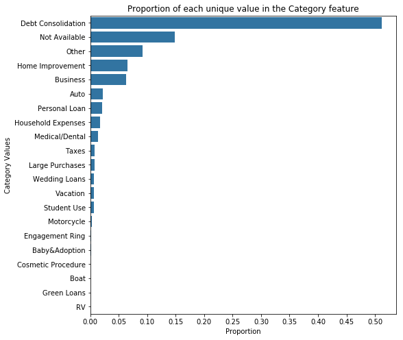

```python
relative_bar('Category')
```

People took most of the loans for debt consolidation...About 50% of the borrowers borrowed to consolidate debt. Only about 7% took loans for business purposes

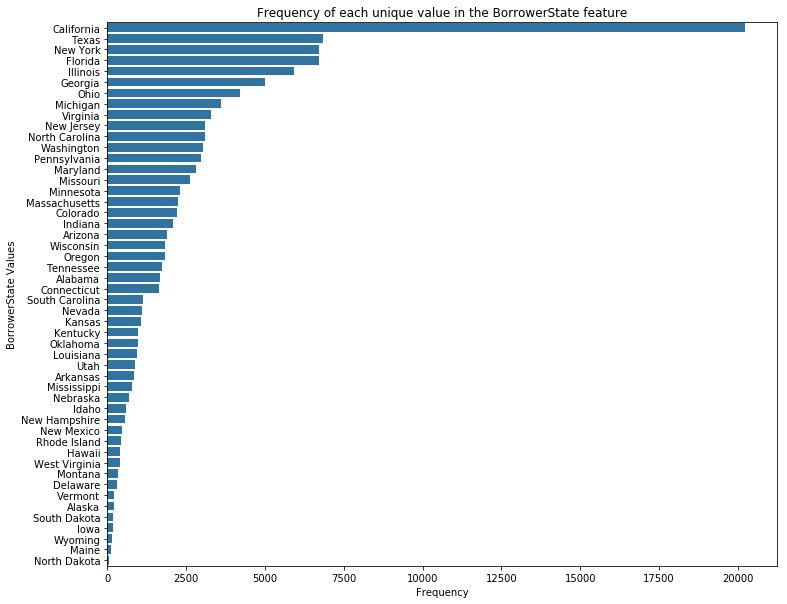

```python
bar_chart('BorrowerState')
```

Most of the borrowers are from CA - California, TX - Texas, NY - New York, FL - Florida, IL - Illinois

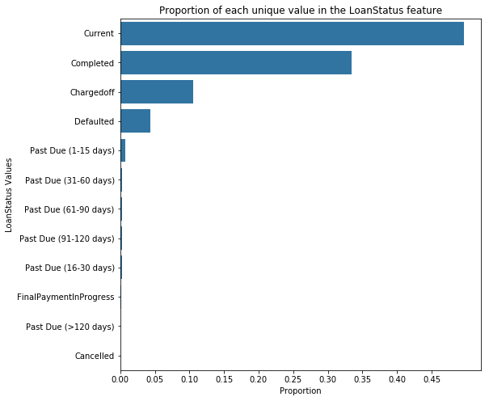

```python
relative_bar('LoanStatus')
```

Most of the loans are currently in payment.

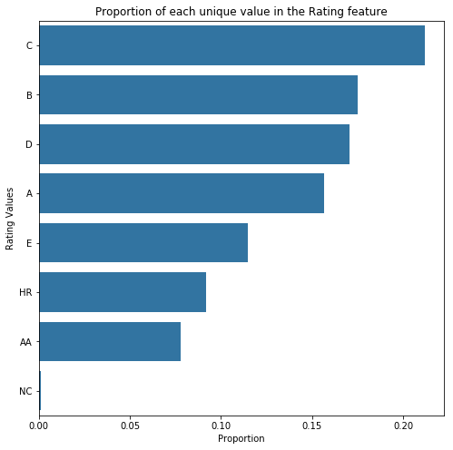

```python
relative_bar("Rating")
```

Most of the borrowers are rated C (which is low-grade); this means the credit agency took more risk than normal.

```python
ct = loan_data['Year'].value_counts().sort_index(ascending=True)
ct
```

```
2005       22
2006     5906
2007    11460
2008    11552
2009     2047
2010     5652
2011    11228
2012    19553
2013    34345
2014    12172
Name: Year, dtype: int64
```

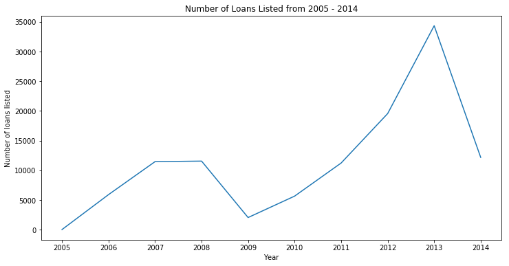

```python
plt.figure(figsize = (12,6));
plt.plot(ct.index.astype('int'), ct.values);
plt.xticks(ct.index.astype('int'));
plt.xlabel('Year');
plt.ylabel('Number of loans listed');
plt.title("Number of Loans Listed from 2005 - 2014");
```

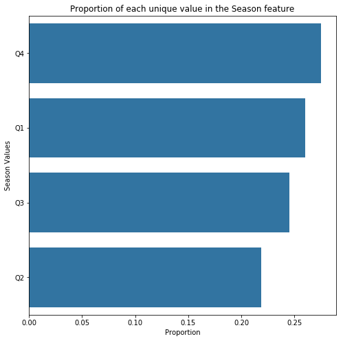

```python
relative_bar('Season')
```

What is the percentage of borrowers that were landowners?

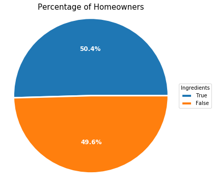

```python
# Use the same pokemon dataset
fig, ax = plt.subplots(figsize=(6, 6));
count = loan_data['Homeowner'].value_counts();
wedges, texts, autotexts = ax.pie(count, labels = count.index, autopct='%.1f%%', wedgeprops={'linewidth': 3.0, 'edgecolor': 'white'}, textprops=dict(color="w"));
plt.axis('equal');
ax.set_title('Percentage of Homeowners', fontsize=15, loc="center");
ax.legend(wedges, count.index ,title="Ingredients",loc="center left",bbox_to_anchor=(1, 0, 0.5, 1));
plt.setp(autotexts, size=12, weight="bold");
```

The proportion of those who own houses and those who do not own is roughly the same.

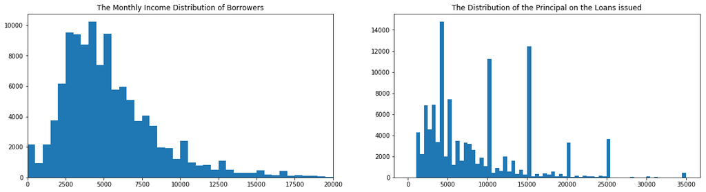

```python
plt.figure(figsize = [20, 5])
base_color = sb.color_palette()[0]

plt.subplot(1, 2, 1)
bins = np.arange(0, loan_data['Monthly_Income'].max()+500, 500)
plt.hist(data = loan_data, x = 'Monthly_Income', bins = bins, color = base_color);
plt.xlim((0,20000))
plt.title("The Monthly Income Distribution of Borrowers");

## I used the xlim parameter here because most of the loans disbursed are within this range

plt.subplot(1, 2, 2) # 1 row, 2 cols, subplot 2
bins = np.arange(0, loan_data['Principal'].max()+500, 500)
plt.hist(data = loan_data, x = 'Principal', bins = bins, color = base_color);
plt.title("The Distribution of the Principal on the Loans issued");
```

```python
np.log10(loan_data['Principal'].describe())
```

```
count    5.056665
mean     3.921011
std      3.795588
min      3.000000
25%      3.602060
50%      3.812913
75%      4.079181
max      4.544068
Name: Principal, dtype: float64
```

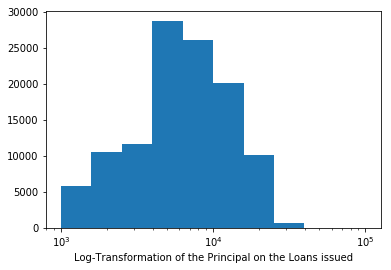

```python
bins = 10 ** np.arange(3, 5+0.2, 0.2)
plt.hist(data=loan_data, x='Principal', bins=bins);
plt.xscale('log');
plt.xlabel('Log-Transformation of the Principal on the Loans issued');
```

```python
loan_data.head(1)
```

|  | Term | LoanStatus | APR | Return | Rating | Category | BorrowerState | Occupation | EmploymentStatus | Work_duration | RevolvingCreditBalance | Homeowner | BankcardUtilization | Monthly_Income | Loan_months | Principal | Investors | Season | Year |
| --- | --- | --- | --- | --- | --- | --- | --- | --- | --- | --- | --- | --- | --- | --- | --- | --- | --- | --- | --- |
| 0 | 36 | Completed | 16.5 | 9.6 | C | Not Available | Colorado | Other | Employed | 2 | 0 | True | 0.0 | 3083 | 78 | 9425 | 258 | Q3 | 2007 |

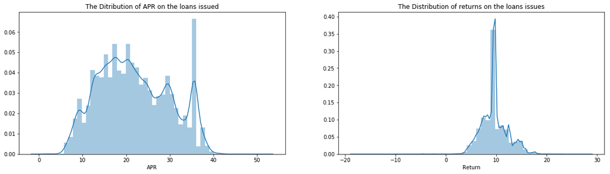

```python
plt.figure(figsize = [20, 5])
base_color = sb.color_palette()[0]

plt.subplot(1, 2, 1)
sb.distplot(loan_data['APR']);
plt.title("The Ditribution of APR on the loans issued");

plt.subplot(1, 2, 2) # 1 row, 2 cols, subplot 2
sb.distplot(loan_data['Return']);
plt.title("The Distribution of returns on the loans issues");
```

[output not shown]

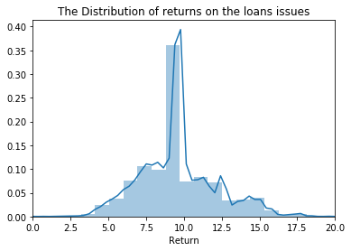

```python
sb.distplot(loan_data['Return']);
plt.title("The Distribution of returns on the loans issues");
plt.xlim((0,20))
```

```python
loan_data['Return'].describe()
```

```
count    113937.000000
mean          9.604852
std           2.622697
min         -18.300000
25%           8.000000
50%           9.600000
75%          10.900000
max          28.400000
Name: Return, dtype: float64
```

```python
len(loan_data[(loan_data['Return'] < 0)])
```

```
195
```

For the univariate explorations, the following were discovered:

## Bivariate Exploration

```python
loan_data.head()
```

|  | Term | LoanStatus | APR | Return | Rating | Category | BorrowerState | Occupation | EmploymentStatus | Work_duration | RevolvingCreditBalance | Homeowner | BankcardUtilization | Monthly_Income | Loan_months | Principal | Investors | Season | Year |
| --- | --- | --- | --- | --- | --- | --- | --- | --- | --- | --- | --- | --- | --- | --- | --- | --- | --- | --- | --- |
| 0 | 36 | Completed | 16.5 | 9.6 | C | Not Available | Colorado | Other | Employed | 2 | 0 | True | 0.0 | 3083 | 78 | 9425 | 258 | Q3 | 2007 |
| 1 | 36 | Current | 12.0 | 5.5 | A | Home Improvement | Colorado | Professional | Employed | 44 | 3989 | False | 21.0 | 6125 | 0 | 10000 | 1 | Q1 | 2014 |
| 2 | 36 | Completed | 28.3 | 9.6 | HR | Not Available | Georgia | Other | Other | 96 | 17598 | False | 56.1 | 2083 | 86 | 3001 | 41 | Q1 | 2007 |
| 3 | 36 | Current | 12.5 | 6.0 | A | Motorcycle | Georgia | Skilled Labor | Employed | 113 | 1444 | True | 4.0 | 2875 | 16 | 10000 | 158 | Q4 | 2012 |
| 4 | 36 | Current | 24.6 | 9.1 | D | Home Improvement | Minnesota | Executive | Employed | 44 | 6193 | True | 81.0 | 9583 | 6 | 15000 | 20 | Q3 | 2013 |

```python
def scatter(col1,col2):
    plt.figure(figsize = (8,8));
    base_color = sb.color_palette()[0];

    ax = sb.regplot(data = loan_data, x = col1, y = col2, color = base_color);
    plt.xlabel(col1)
    plt.ylabel(col2)
    plt.title("Scatter Plot showing correlation between " + col2 + " and " + col1)
```

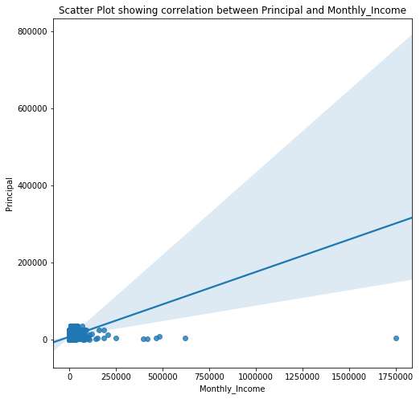

```python
scatter("Monthly_Income", "Principal")
```

```python
## This scatter plot reveals the presence of outliers. Let's remove the outliers by capping the values at 75000
```

```python
loan_data['Monthly_Income'][loan_data['Monthly_Income'] > 75000] = 75000
```

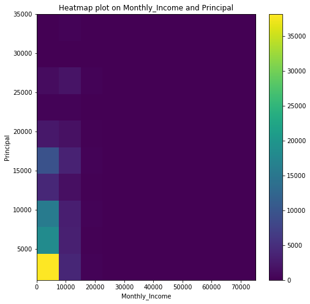

```python
plt.figure(figsize = (8,8));
base_color = sb.color_palette()[0];
ax = plt.hist2d(data = loan_data, x = 'Monthly_Income', y = 'Principal')
plt.colorbar()
plt.xlabel('Monthly_Income')
plt.ylabel('Principal');
plt.title("Heatmap plot on Monthly_Income and Principal");
```

```python
"""
def sq_trans(x, inverse = False):
    if not inverse:
        return np.sqrt(x)
    else:
        return x**2

def log_trans(x, inverse = False):
    if not inverse:
        return np.log10(x)
    else:
        return np.power(10, x)

plt.figure(figsize = (12,10));
base_color = sb.color_palette()[0];
ax = sb.regplot(loan_data["Monthly_Income"].apply(sq_trans), y = loan_data["Principal"].apply(log_trans), color = base_color);
plt.xlabel("Monthly_Income")
plt.ylabel("Principal")
plt.title("Scatter Plot showing correlation between Monthly_Income Principal")

"""
```

[output not shown]

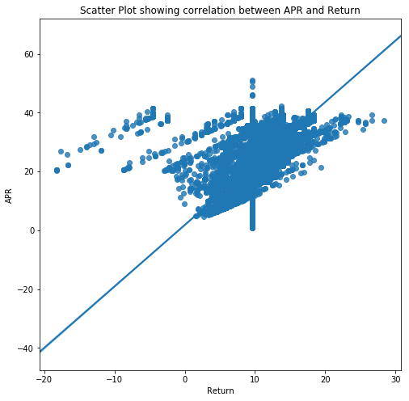

```python
scatter("Return", "APR")
```

There is a positive relationship between the Annual Percentage Rate on the loan and return on the loan for the credit agency.

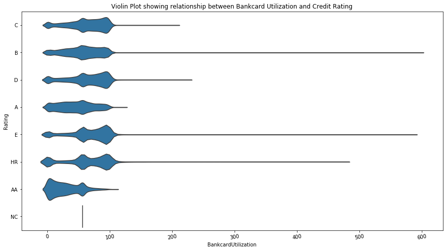

```python
ct = loan_data['Rating'].value_counts()
plt.figure(figsize = [15, 8])
base_color = sb.color_palette()[0]
sb.violinplot(data=loan_data, y='Rating', x='BankcardUtilization', color=base_color, order = ct.index, inner=None)
plt.xticks(rotation=10);
plt.title("Violin Plot showing relationship between Bankcard Utilization and Credit Rating");
```

The ones rated very high had low bank card utilzation. the ones rated low (C,D,E,and HR) had higher bank card utilization. This is not strange as it suggest that they borrowed more often

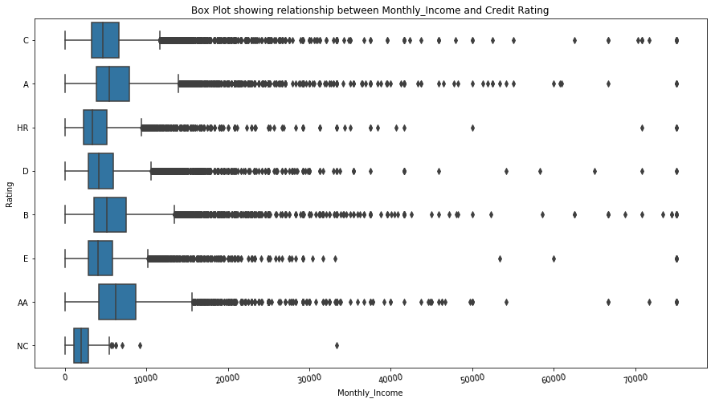

```python
plt.figure(figsize = [15, 8])
base_color = sb.color_palette()[0]
sb.boxplot(data=loan_data, y='Rating', x='Monthly_Income', color=base_color)
plt.xticks(rotation=10);
plt.title("Box Plot showing relationship between Monthly_Income and Credit Rating");
```

```python
loan_data.head()
```

|  | Term | LoanStatus | APR | Return | Rating | Category | BorrowerState | Occupation | EmploymentStatus | Work_duration | RevolvingCreditBalance | Homeowner | BankcardUtilization | Monthly_Income | Loan_months | Principal | Investors | Season | Year |
| --- | --- | --- | --- | --- | --- | --- | --- | --- | --- | --- | --- | --- | --- | --- | --- | --- | --- | --- | --- |
| 0 | 36 | Completed | 16.5 | 9.6 | C | Not Available | Colorado | Other | Employed | 2 | 0 | True | 0.0 | 3083 | 78 | 9425 | 258 | Q3 | 2007 |
| 1 | 36 | Current | 12.0 | 5.5 | A | Home Improvement | Colorado | Professional | Employed | 44 | 3989 | False | 21.0 | 6125 | 0 | 10000 | 1 | Q1 | 2014 |
| 2 | 36 | Completed | 28.3 | 9.6 | HR | Not Available | Georgia | Other | Other | 96 | 17598 | False | 56.1 | 2083 | 86 | 3001 | 41 | Q1 | 2007 |
| 3 | 36 | Current | 12.5 | 6.0 | A | Motorcycle | Georgia | Skilled Labor | Employed | 113 | 1444 | True | 4.0 | 2875 | 16 | 10000 | 158 | Q4 | 2012 |
| 4 | 36 | Current | 24.6 | 9.1 | D | Home Improvement | Minnesota | Executive | Employed | 44 | 6193 | True | 81.0 | 9583 | 6 | 15000 | 20 | Q3 | 2013 |

```python
numeric_vars = ['APR', 'Return', 'Work_duration','RevolvingCreditBalance', 'BankcardUtilization',
                'Monthly_Income','Loan_months','Principal','Investors']
categoric_vars = ['LoanStatus', 'Rating', 'Category','BorrowerState','Occupation','EmploymentStatus',
                 'Homeowner','Season','Year']
```

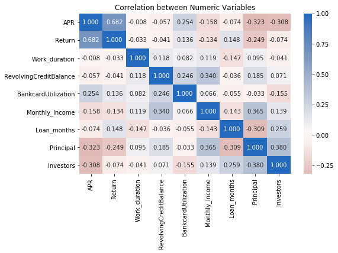

```python
# correlation plot
plt.figure(figsize = [8, 5]);
sb.heatmap(loan_data[numeric_vars].corr(), annot = True, fmt = '.3f',
           cmap = 'vlag_r', center = 0);
plt.title('Correlation between Numeric Variables');
```

Only APR and Return has a strong positve correlation.

```python
"""g = sb.PairGrid(data = loan_data, vars = numeric_vars)
g = g.map_diag(plt.hist, bins = 20);
g.map_offdiag(plt.scatter);"""
```

```
'g = sb.PairGrid(data = loan_data, vars = numeric_vars)\ng = g.map_diag(plt.hist, bins = 20);\ng.map_offdiag(plt.scatter);'
```

```python
def heat_values(col):
    ct_counts = loan_data.groupby(['LoanStatus', col]).size()
    ct_counts = ct_counts.reset_index(name='count')
    ct_counts = ct_counts.pivot(index = 'LoanStatus', columns = col, values = 'count')
    plt.figure(figsize = [8, 8])
    sb.heatmap(ct_counts,annot = True, fmt = '.0f')
    plt.title('Heatmap showing relationship between Loan Status and ' + col)
```

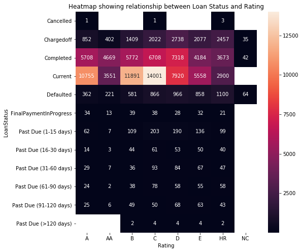

```python
heat_values('Rating')
```

- C,D, E, and HR rated borrowers defaulted the most. The lower the rating, the higher the risk of default.
- Most loans currently in payment were borrowed by C-rated clients

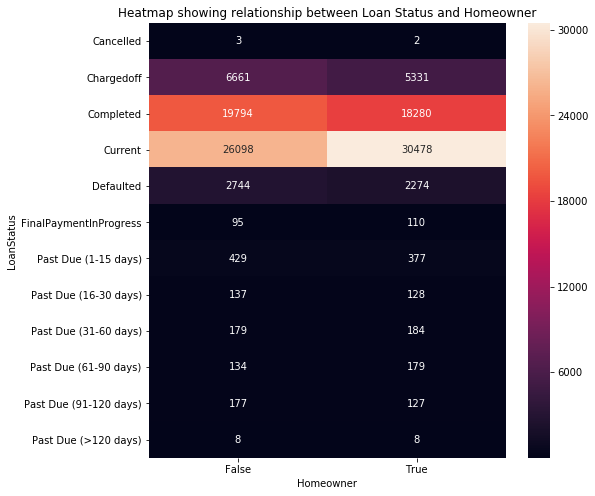

```python
heat_values('Homeowner')
```

```python
def biv_bar(data):
    count = loan_data['LoanStatus'].value_counts()
    order = count.index

    n_ = loan_data['LoanStatus'].value_counts().sum()
    max_count = count[0]
    max_prop = max_count / n_
    # establish tick locations and create plot
    base_color = sb.color_palette()[0]
    ticks = np.arange(0, max_prop, 0.05)
    tick_names = ['{:0.2f}'.format(v) for v in ticks]

    plt.figure(figsize = (10,8));
    base_color = sb.color_palette()[0];
    ax = sb.countplot(data=loan_data, x= 'LoanStatus', hue = data, order = order);
    plt.yticks(ticks * n_, tick_names)
    plt.xlabel("Percentage of " + data + " Represented")
    plt.ylabel("Loan Status")
    plt.title('Relationship of LoanStatus with the ' + data + " feature")
    ax.legend(loc = 1, framealpha = 1)
    plt.xticks(rotation = 90)
```

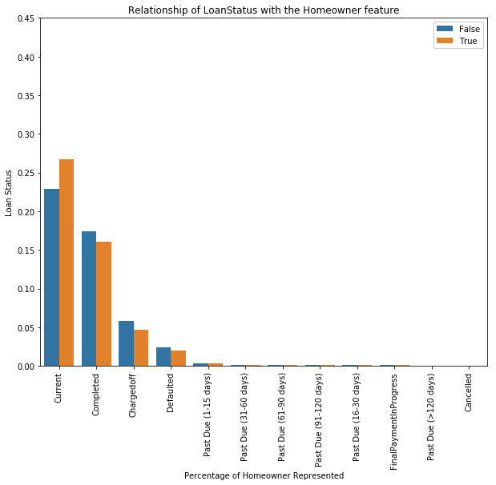

```python
biv_bar('Homeowner')
```

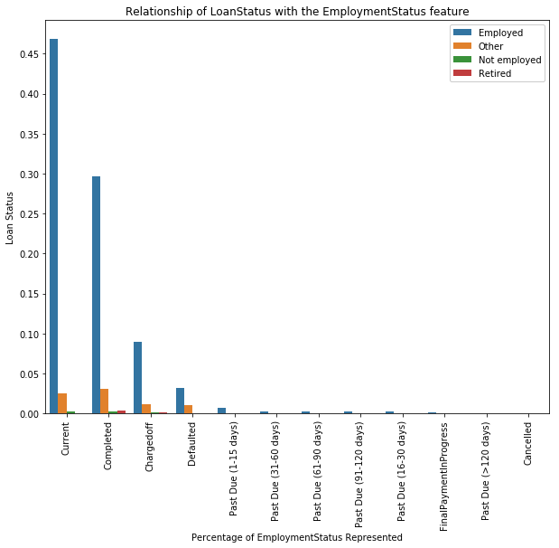

```python
biv_bar('EmploymentStatus')
```

By far, the employed ones who took more loans than the other categories

For the bivariate explorations, the following were discovered:

- The employed ones who took more loans than those in the other categories
- The ones rated very high had low bank card utilzation. the ones rated low (C,D,E,and HR) had higher bank card utilization. This is not strange as it suggest that they took loans more often
- There is a positive relationship between the Annual Percentage Rate on the loan and return on the loan for the credit agency.
- C,D, E, and HR rated borrowers defaulted the most. The lower the rating, the higher the risk of default.
- Most loans currently in payment were borrowed by C-rated client

## Multivariate Exploration

```python
def facet(var1, var2, hue):
    g = sb.FacetGrid(data = loan_data, hue = hue, size = 5, palette = 'colorblind');
    g.map(plt.scatter, var1, var2);
    g.add_legend();
    plt.title("Multivariate exploration between variables " + var1 + ", " + var2 + " ,and " + hue)
```

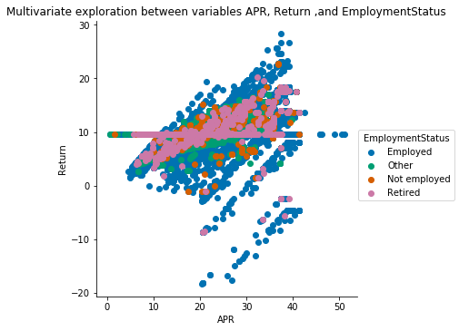

```python
facet('APR', 'Return', 'EmploymentStatus')
```

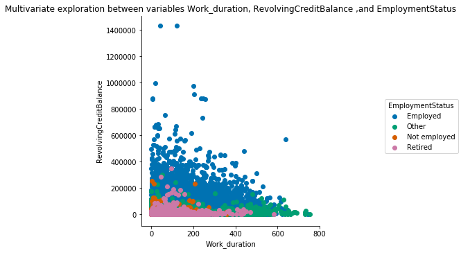

```python
facet('Work_duration', 'RevolvingCreditBalance', 'EmploymentStatus')
```

The unemployed ones have small work duration and little revolving credit balance

```python
"""
g = sb.FacetGrid(data = loan_data, col = 'Rating', row = 'Homeowner', size = 2.5,
                margin_titles = True)
"""
```

```
"\ng = sb.FacetGrid(data = loan_data, col = 'Rating', row = 'Homeowner', size = 2.5,\n                margin_titles = True)\n"
```

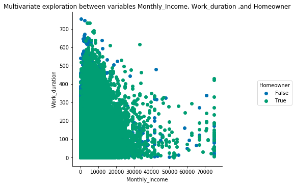

```python
facet('Monthly_Income', 'Work_duration', 'Homeowner')
```

Borrowers who are homeonwers are likely to have a higher monthly income

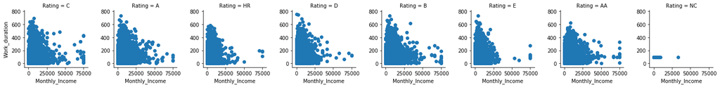

```python
g = sb.FacetGrid(data = loan_data, col = 'Rating', size = 2.5, margin_titles = False)
g.map(plt.scatter, 'Monthly_Income', 'Work_duration');
```

It doesn't seem that monthly income determines the quality of borrowers' credit rating. The same thing goes with work_duration. Those who had worked for long didnt necesarily have good credit ratings

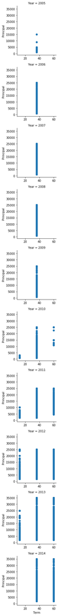

```python
g = sb.FacetGrid(data = loan_data, row = 'Year', size = 3,
                margin_titles = False);
g.map(plt.scatter,'Term','Principal');
```

- The credit agency has issued bigger loans than usual in 2013 and 2014. Before then, loans barely crosssed the 25000 mark
- The agency started issuing different term loans in 2010 and in 2014 particularly has issued loan >=36 months

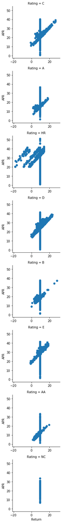

```python
g = sb.FacetGrid(data = loan_data, row = 'Rating', size = 3, margin_titles = False)
g.map(plt.scatter,'Return','APR');
```

It becomes very clear now that the loans that resulted in negative returns for the credit agency were borrowed by HR-rated borrowers which is the lowest grade. They had the highest APR as well, which is not strange as the APR compensates for the risk the agency takes by issuing the loan. In summary, this means the lower your rating, the more the APR and the more the likelihood of default.

For the mulitvariate explorations, the following were discovered:

- The lower the rating, the more the APR and the more the likelihood of default.
- Borrowers rated B, C and D yielded the highest returns for the credit agency
- It doesn't seem that monthly income determines the quality of borrowers' credit rating. The same thing goes with work_duration. Those who had worked for long didnt necesarily have good credit ratings
- Borrowers who are homeonwers are likely to have a higher monthly income
- The unemployed ones have small work duration and little revolving credit balance
- The biggest loans were listed in 2013 and 2014